# **Introduction to my Data Analysis Project**

### 9. Director Analysis (United States vs non-United States)

There are 2117 directors releasing movies/TV shows in the United States and 2464 directors releasing movies/TV shows outside the United States. It is to note that some of these directors releasing movies/TV shows in the US may also release movies internationally as well.

```
Number of different Directors: 2117
```

[figure not shown]

```python
united_states = df_netflix[df_netflix["country"].str.contains("United States",na=False)]
list_director = [x.split(', ') for x in united_states.dropna(subset=['director'])['director'].tolist()]
list_director = list(itertools.chain(*list_director))
df_netflix_director_count = pd.DataFrame(Counter(list_director).most_common()[:], columns=['director', 'Count'])
print("Number of different Directors:",len(df_netflix_director_count))
df_netflix_cast_count = pd.DataFrame(Counter(list_director).most_common()[:10], columns=['director', 'Count'])
print()
plt.figure(figsize=(25,7))
plt.title('Top 10 US directors available on Netflix', fontsize=18)
plt.tick_params(labelsize=14)
sns.barplot(y="Count", x='director', data=df_netflix_cast_count, palette="Set2", orient='v')
plt.xlabel('Count', fontsize=14)
plt.ylabel('Director Name', fontsize=14)

plt.show()
```

```
Number of different Directors: 2464
```

[figure not shown]

```python
non_united_states = df_netflix[~df_netflix["country"].str.contains("United States",na=False)]
list_director = [x.split(', ') for x in non_united_states.dropna(subset=['director'])['director'].tolist()]
list_director = list(itertools.chain(*list_director))

df_netflix_director_count = pd.DataFrame(Counter(list_director).most_common()[:], columns=['director', 'Count'])
print("Number of different Directors:",len(df_netflix_director_count))
df_netflix_director_count = pd.DataFrame(Counter(list_director).most_common()[:10], columns=['director', 'Count'])
print()
plt.figure(figsize=(25,7))
plt.title('Top 10 Non-US directors available on Netflix', fontsize=18)
plt.tick_params(labelsize=14)
sns.barplot(y="Count", x='director', data=df_netflix_director_count, palette="Set2", orient='v')
plt.xlabel('Count', fontsize=14)
plt.ylabel('Director Name', fontsize=14)

plt.show()
```

### 10. Cast Analysis

The bar chart below shows the cast that have the most releases on Netflix. There were a total of 32,881 cast members in the database.

```
Number of different Cast Members: 32881
```

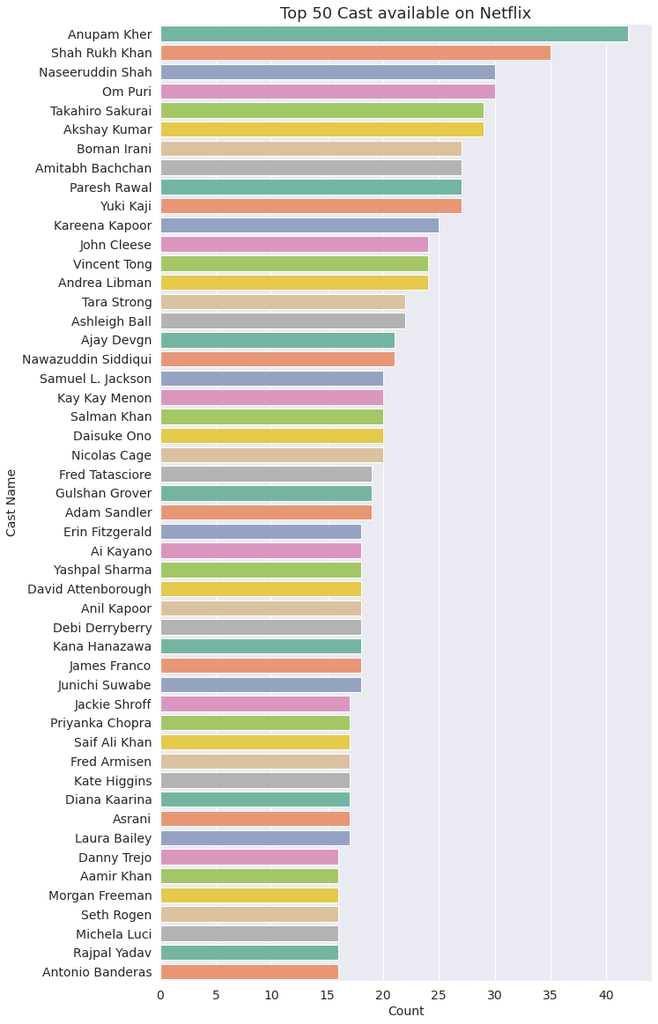

```python
list_cast = [x.split(', ') for x in df_netflix.dropna(subset=['cast'])['cast'].tolist()]
list_cast = list(itertools.chain(*list_cast))
df_netflix_cast_count = pd.DataFrame(Counter(list_cast).most_common()[:], columns=['Cast', 'Count'])
print("Number of different Cast Members:",len(df_netflix_cast_count))
df_netflix_cast_count = pd.DataFrame(Counter(list_cast).most_common()[:50], columns=['Cast', 'Count'])
print()
plt.figure(figsize=(10,20))
plt.title('Top 50 Cast available on Netflix', fontsize=18)
plt.tick_params(labelsize=14)
sns.barplot(y=df_netflix_cast_count.Cast, x=df_netflix_cast_count.Count, palette="Set2")
plt.xlabel('Count', fontsize=14)
plt.ylabel('Cast Name', fontsize=14)
plt.show()
```

### 11. Cast Analysis (United States vs non-United States)

There are 13,786 cast members with movies/TV shows in the United States and 21,222 cast members with movies/TV shows outside the United States. It is to note that some of these directors releasing movies in the US may also release movies/TV shows internationally as well.

```
Number of different Cast Members: 13786
```

[figure not shown]

```python
united_states = df_netflix[df_netflix["country"].str.contains("United States",na=False)]
list_cast = [x.split(', ') for x in united_states.dropna(subset=['cast'])['cast'].tolist()]
list_cast = list(itertools.chain(*list_cast))
df_netflix_cast_count = pd.DataFrame(Counter(list_cast).most_common()[:], columns=['Cast', 'Count'])
print("Number of different Cast Members:",len(df_netflix_cast_count))
df_netflix_cast_count = pd.DataFrame(Counter(list_cast).most_common()[:10], columns=['Cast', 'Count'])
print()
#print(list_cast)
plt.figure(figsize=(18,10))
ax = sns.barplot(y="Count", x='Cast', data=df_netflix_cast_count, palette="Set2", orient='v')
ax.set(xlabel='Cast', ylabel='Number of releases')
plt.ylabel('Count', fontsize=14)
plt.xlabel('Cast Name', fontsize=14)
plt.title('Top 10 US Cast available on Netflix', fontsize=18)
```

```
Number of different Cast Members: 21222
```

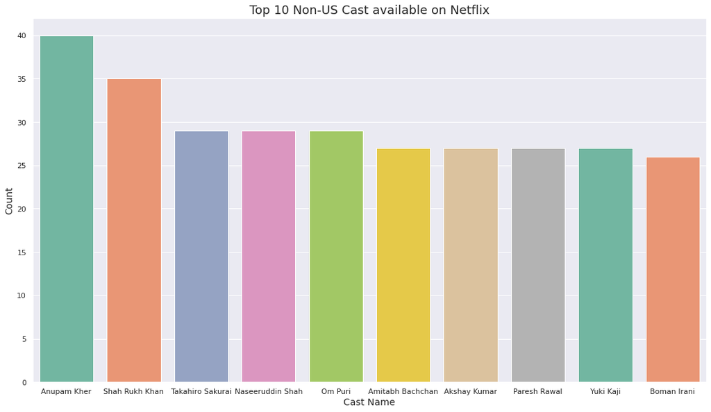

```python
non_united_states = df_netflix[~df_netflix["country"].str.contains("United States",na=False)]
list_cast = [x.split(', ') for x in non_united_states.dropna(subset=['cast'])['cast'].tolist()]
list_cast = list(itertools.chain(*list_cast))
df_netflix_cast_count = pd.DataFrame(Counter(list_cast).most_common()[:], columns=['Cast', 'Count'])
print("Number of different Cast Members:",len(df_netflix_cast_count))
df_netflix_cast_count = pd.DataFrame(Counter(list_cast).most_common()[:10], columns=['Cast', 'Count'])
print()
#print(list_cast)
plt.figure(figsize=(18,10))
ax = sns.barplot(y="Count", x='Cast', data=df_netflix_cast_count, palette="Set2", orient='v')
ax.set(xlabel='Cast', ylabel='Number of releases')
plt.ylabel('Count', fontsize=14)
plt.xlabel('Cast Name', fontsize=14)
plt.title('Top 10 Non-US Cast available on Netflix', fontsize=18)
```

## **Follow up Questions.**

I really enjoyed investigating this dataset and I will definitely spend more time figuring things out and relations between the columns/variables. I would like to use this data and combine it with another database such as IMDB so that I can create a database that will allow me to see how good the movie is. Additionally, I would like to replicate the recommendation feed that Netflix produces using NLP databases provided by sources like Google. Maybe if I had more time on my hand and the availability of data to platforms like Hulu and HBO, I could even generate a bigger database showing all movies/tv shows and what platform they are free to watch on. Thank you for taking the time to read through this blog and my data analysis of Netflix.

### **Blog Link**

Link: [https://chrislim1234.github.io/](https://chrislim1234.github.io/index.html)